# Lab6_v1

Anna Matarazzo

10/22/2020

## Problem 1

1. Write a function that conducts a randomization test for the mean difference between two groups, and show that it works. Specifically, using your function, conduct a randomization test on the same data we used in the above example from lab. Report the results and briefly discuss what the results of the randomization tell you. (6 points). Extra: if the observed mean difference in the experiment was found to be .5, what would you have concluded from the randomization test?

Inputs: - the inputs should include a vector for group 1, and vector for group 2, and the number of permutations/re-samplings of the data to create.

Outputs: - output each group mean, and the difference between group means - output a histogram of the sampling distribution of the possible mean differences produced by the randomization process - output the probability or odds of obtaining the observed mean difference or larger.

Optional:

- include the ability to calculate the probability of obtaining any mean difference or larger
- deal with negative difference scores appropriately
- add one or two-tailed test options

```r
group_one <- c(3,4,5,6,7)
group_two <- c(5,3,2,4,6)

library(dplyr)
```

```
## $A_mean
## [1] 5
##
## $B_mean
## [1] 4
##
## $difference
## [1] 1
##
## $randomization
##    [1]  1.0  0.2 -0.2 -1.0 -1.0 -0.2  0.2 -1.0 -0.6  0.6 -1.4  0.2  0.2 -0.2
##   [15] -0.2  1.8 -0.2 -2.2  0.2 -0.6 -1.0  0.6  0.6 -1.0  0.6 -1.0  1.0 -1.0
##   [29]  0.6 -1.4 -1.4  0.2 -0.2 -1.0 -0.6 -0.6 -2.2 -0.6  0.2  0.2  0.2 -1.4
##   [43]  0.2 -0.2  2.2  1.8  0.6  1.0 -0.2 -0.6  2.6  0.2  0.6  1.4 -1.0 -0.6
##   [57] -1.0  0.6 -1.4  0.2 -1.8  0.2 -0.2 -0.6 -0.6 -0.6  0.6  0.6  0.6  0.2
```

[output cut: 72 more lines]

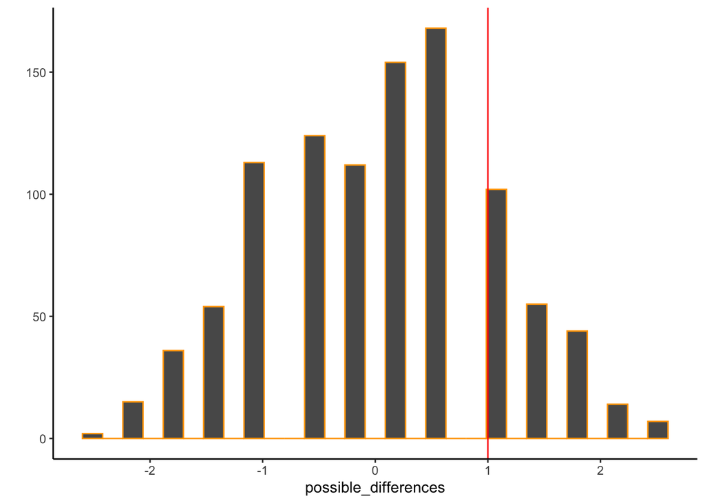

```
##
## $p_value
## [1] 0.222
```

```r
randomization_test <- function(A, B, resamples = 1000) {

  group_A_mean <- mean(A)
  group_B_mean <- mean(B)
  mean_difference <- group_A_mean - group_B_mean

 all_means <- c(A,B)

 possible_differences <- c()
 for(i in 1:resamples){
  resample <- sample(all_means)
  new_A_mean <- mean(resample[1:length(A)])
  new_B_mean <- mean(resample[(length(A)+1):length(all_means)])
  possible_differences[i] <- new_A_mean - new_B_mean


}

 the_plot <- ggplot2::qplot(possible_differences)+
  ggplot2::geom_histogram(color="orange")+
  ggplot2::geom_vline(xintercept=mean_difference, color = "red")+
  ggplot2::theme_classic()


# absolute_differences <- abs(possible_differences)

  p_value <- length(possible_differences[possible_differences >= mean_difference ] )/resamples

  st_dev <- sd(possible_differences)


 test_output <- list(A_mean = group_A_mean,
                     B_mean = group_B_mean,
                     difference = mean_difference,
                     randomization = possible_differences,
                     standard_deviation = st_dev,
                     plot = the_plot,
                     p_value = p_value)

 return(test_output)
}

randomization_test(A = group_one,
                   B = group_two,
                   resamples = 1000)
```

```r
the_data <- read.csv("open_data/SchroederEpley2015data.csv", header = TRUE)

library(dbplyr)
group_0 <- the_data %>%
  filter(CONDITION == 0)%>%
  select(Intellect_Rating)

group_0 <-group_0$Intellect_Rating

group_1 <- the_data %>%
  filter(CONDITION == 1)%>%
  select(Intellect_Rating)

group_1 <-group_1$Intellect_Rating

randomization_test(A=group_1,
                   B=group_0,
                   resamples = 1000)
```

```
## $A_mean
## [1] 5.634921
##
## $B_mean
## [1] 3.648148
##
## $difference
## [1] 1.986772
##
## $randomization
##    [1]  0.164021164  0.473544974  0.439153439  0.095238095  0.164021164
##    [6] -0.145502646 -0.317460317  0.714285714  1.470899471 -0.558201058
##   [11]  0.576719577 -0.420634921  1.367724868 -0.455026455  0.645502646
##   [16] -0.145502646  0.989417989  0.026455026  0.026455026  0.920634921
##   [21] -0.007936508  0.783068783 -0.936507937  1.058201058 -0.420634921
```

[output cut: 200 more lines]

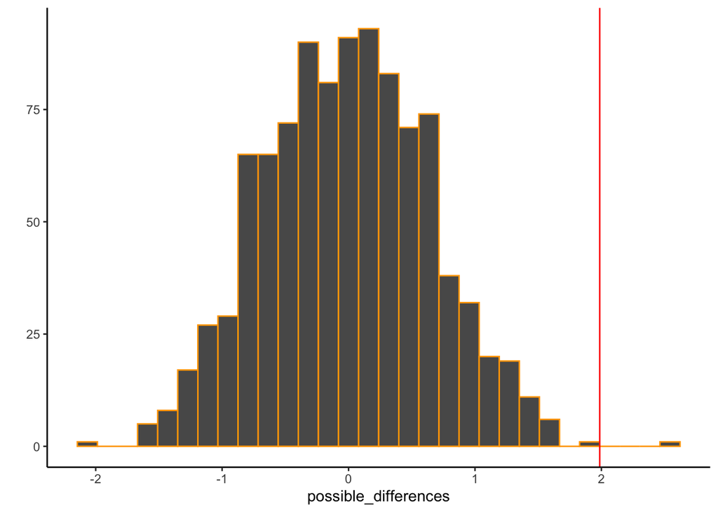

```
##
## $p_value
## [1] 0.001
```

#### The simulation shows us that the actual mean difference is unlikely to be due to chance because it is very close to the distribution tail(s). If the observed mean difference in the experiment was found to be .5 it would be close to the mean (looks like it’s within 0.6-0.7 standard deviations from the mean), so this result would be very likely to be due to chance.

######Below I tried to find out what is the probability of getting Jenny’s number if we randomly sample numbers from 0 to 9, and if we randomly sample only numbers 8675309. I kept it here because I want to finish working on it so that it presents a nice output.

```r
a <- sample(x = 0:9, size = 7, replace = FALSE)
samples <- replicate(100000, sample(a))

count_example <- 0
for(i in 1:100000){
  if(sum (samples[,i] == c(8,6,7,5,3,0,9)) == 7) {
    count_example <-  count_example+1
  }
}

count_example
```

```
## [1] 0
```

```r
count_example/100000
```

```
## [1] 0
```

```r
n=100000
samples <- replicate(n, sample(c(0,3,5,6,7,8,9)))

count_example <- 0
for(i in 1:n){
  if(sum (samples[,i] == c(8,6,7,5,3,0,9)) == 7) {
    count_example <-  count_example+1
  }
}

count_example
```

```
## [1] 12
```

```r
count_example/n*100
```

```
## [1] 0.012
```

```r
#output <- list (number_of_jennys_numbers = count_example,
                # probability_percent = b)
```